# Introduction

```
 Dans le contexte actuel, l'octroi de crédits bancaires est une décision cruciale pour les institutions financières, car elle implique une évaluation minutieuse de la solvabilité des demandeurs. Une mauvaise décision peut entraîner des pertes financières importantes pour la banque. Avec l'avènement des technologies avancées de l'intelligence artificielle et de l'apprentissage automatique, il est désormais possible de prédire avec une précision accrue si un demandeur de crédit est susceptible d'être risqué ou non.

 Ce projet se concentre sur l'analyse et la classification des individus en deux catégories : "crédit risqué" et "crédit non risqué", en utilisant des données historiques et des techniques d'apprentissage automatique. Le dataset utilisé, connu sous le nom de "german.data", contient divers attributs financiers et personnels des demandeurs, et sert de base à notre analyse. Le but ultime de ce projet est de développer un modèle prédictif fiable qui peut aider les institutions financières à prendre des décisions plus informées et réduire le risque de défaut de paiement.
```

## Data Collection

```
Import Libraries
```

```python
import numpy as np
import pandas as pd
import seaborn as sns
from scipy import stats
import scikitplot as skplt
from math import floor,ceil
import statsmodels.api as sm
import matplotlib.pyplot as plt
from xgboost import XGBClassifier
from sklearn.decomposition import PCA
from IPython.display import display, HTML
pd.set_option('display.max_columns', None)
from sklearn.model_selection import GridSearchCV
from sklearn.metrics import accuracy_score, confusion_matrix,roc_curve
from sklearn.model_selection import train_test_split, KFold, cross_val_score


import warnings
warnings.simplefilter('ignore', DeprecationWarning)
```

```python
def style_specific_cell(x):

    color_thresh = 'background-color: lightpink'

    df_color = pd.DataFrame('', index=x.index, columns=x.columns)
    rows_number=len(x.index)
    column_number=len(x.columns)
    for r in range(0,rows_number):
        for c in range(0,column_number):
            try:
                val=float(x.iloc[r, c])
                if x.iloc[r, 0]=="Percentage":
                    if val<10:
                        df_color.iloc[r, c]=color_thresh
            except:
                pass

    return df_color

def style_stats_specific_cell(x):

    color_thresh = 'background-color: lightpink'

    df_color = pd.DataFrame('', index=x.index, columns=x.columns)
    rows_number=len(x.index)
    for r in range(0,rows_number):
        try:
            val=(x.iloc[r, 1])
            if val>0.05:
                df_color.iloc[r, 1]=color_thresh
        except:
            pass
    return df_color
```

# Import Data

```
Import data from UCI machine learning repository.
link: http://archive.ics.uci.edu/ml/machine-learning-databases/statlog/german/german.data
```

```python
#Reading Dataset from  http://archive.ics.uci.edu/ml/machine-learning-databases/statlog/german/german.data
df=pd.read_csv("german_credit_data.csv",sep=" ",header=None)
headers=["Status of existing checking account","Duration in month","Credit history",\
         "Purpose","Credit amount","Savings account/bonds","Present employment since",\
         "Installment rate in percentage of disposable income","Personal status and sex",\
         "Other debtors / guarantors","Present residence since","Property","Age in years",\
        "Other installment plans","Housing","Number of existing credits at this bank",\
        "Job","Number of people being liable to provide maintenance for","Telephone","foreign worker","Cost Matrix(Risk)"]
df.columns=headers
df.to_csv("german_data_credit_cat.csv",index=False) #save as csv file

#for structuring only
Status_of_existing_checking_account={'A14':"no checking account",'A11':"<0 DM", 'A12': "0 <= <200 DM",'A13':">= 200 DM "}
df["Status of existing checking account"]=df["Status of existing checking account"].map(Status_of_existing_checking_account)

Credit_history={"A34":"critical account","A33":"delay in paying off","A32":"existing credits paid back duly till now","A31":"all credits at this bank paid back duly","A30":"no credits taken"}
df["Credit history"]=df["Credit history"].map(Credit_history)

Purpose={"A40" : "car (new)", "A41" : "car (used)", "A42" : "furniture/equipment", "A43" :"radio/television" , "A44" : "domestic appliances", "A45" : "repairs", "A46" : "education", 'A47' : 'vacation','A48' : 'retraining','A49' : 'business','A410' : 'others'}
df["Purpose"]=df["Purpose"].map(Purpose)

Saving_account={"A65" : "no savings account","A61" :"<100 DM","A62" : "100 <= <500 DM","A63" :"500 <= < 1000 DM", "A64" :">= 1000 DM"}
df["Savings account/bonds"]=df["Savings account/bonds"].map(Saving_account)

Present_employment={'A75':">=7 years", 'A74':"4<= <7 years",  'A73':"1<= < 4 years", 'A72':"<1 years",'A71':"unemployed"}
df["Present employment since"]=df["Present employment since"].map(Present_employment)



Personal_status_and_sex={ 'A95':"female:single",'A94':"male:married/widowed",'A93':"male:single", 'A92':"female:divorced/separated/married", 'A91':"male:divorced/separated"}
df["Personal status and sex"]=df["Personal status and sex"].map(Personal_status_and_sex)


Other_debtors_guarantors={'A101':"none", 'A102':"co-applicant", 'A103':"guarantor"}
df["Other debtors / guarantors"]=df["Other debtors / guarantors"].map(Other_debtors_guarantors)


Property={'A121':"real estate", 'A122':"savings agreement/life insurance", 'A123':"car or other", 'A124':"unknown / no property"}
df["Property"]=df["Property"].map(Property)




Other_installment_plans={'A143':"none", 'A142':"store", 'A141':"bank"}
df["Other installment plans"]=df["Other installment plans"].map(Other_installment_plans)

Housing={'A153':"for free", 'A152':"own", 'A151':"rent"}
df["Housing"]=df["Housing"].map(Housing)




Job={'A174':"management/ highly qualified employee", 'A173':"skilled employee / official", 'A172':"unskilled - resident", 'A171':"unemployed/ unskilled  - non-resident"}
df["Job"]=df["Job"].map(Job)

Telephone={'A192':"yes", 'A191':"none"}
df["Telephone"]=df["Telephone"].map(Telephone)



foreign_worker={'A201':"yes", 'A202':"no"}
df["foreign worker"]=df["foreign worker"].map(foreign_worker)



risk={1:"Good Risk", 2:"Bad Risk"}
df["Cost Matrix(Risk)"]=df["Cost Matrix(Risk)"].map(risk)
```

# Data Overview

```python
df.head() #top 5 rows of the dataset
```

|  | Status of existing checking account | Duration in month | Credit history | Purpose | Credit amount | Savings account/bonds | Present employment since | Installment rate in percentage of disposable income | Personal status and sex | Other debtors / guarantors | Present residence since | Property | Age in years | Other installment plans | Housing | Number of existing credits at this bank | Job | Number of people being liable to provide maintenance for | Telephone | foreign worker | Cost Matrix(Risk) |
| --- | --- | --- | --- | --- | --- | --- | --- | --- | --- | --- | --- | --- | --- | --- | --- | --- | --- | --- | --- | --- | --- |
| 0 | <0 DM | 6 | critical account | radio/television | 1169 | no savings account | >=7 years | 4 | male:single | none | 4 | real estate | 67 | none | own | 2 | skilled employee / official | 1 | yes | yes | Good Risk |
| 1 | 0 <= <200 DM | 48 | existing credits paid back duly till now | radio/television | 5951 | <100 DM | 1<= < 4 years | 2 | female:divorced/separated/married | none | 2 | real estate | 22 | none | own | 1 | skilled employee / official | 1 | none | yes | Bad Risk |
| 2 | no checking account | 12 | critical account | education | 2096 | <100 DM | 4<= <7 years | 2 | male:single | none | 3 | real estate | 49 | none | own | 1 | unskilled - resident | 2 | none | yes | Good Risk |
| 3 | <0 DM | 42 | existing credits paid back duly till now | furniture/equipment | 7882 | <100 DM | 4<= <7 years | 2 | male:single | guarantor | 4 | savings agreement/life insurance | 45 | none | for free | 1 | skilled employee / official | 2 | none | yes | Good Risk |
| 4 | <0 DM | 24 | delay in paying off | car (new) | 4870 | <100 DM | 1<= < 4 years | 3 | male:single | none | 4 | unknown / no property | 53 | none | for free | 2 | skilled employee / official | 2 | none | yes | Bad Risk |

# Data Info

```python
df.info()
```

```
<class 'pandas.core.frame.DataFrame'>
RangeIndex: 1000 entries, 0 to 999
Data columns (total 21 columns):
 #   Column                                                    Non-Null Count  Dtype
---  ------                                                    --------------  -----
 0   Status of existing checking account                       1000 non-null   object
 1   Duration in month                                         1000 non-null   int64
 2   Credit history                                            1000 non-null   object
 3   Purpose                                                   1000 non-null   object
 4   Credit amount                                             1000 non-null   int64
 5   Savings account/bonds                                     1000 non-null   object
 6   Present employment since                                  1000 non-null   object
 7   Installment rate in percentage of disposable income       1000 non-null   int64
 8   Personal status and sex                                   1000 non-null   object
 9   Other debtors / guarantors                                1000 non-null   object
 10  Present residence since                                   1000 non-null   int64
 11  Property                                                  1000 non-null   object
 12  Age in years                                              1000 non-null   int64
 13  Other installment plans                                   1000 non-null   object
 14  Housing                                                   1000 non-null   object
 15  Number of existing credits at this bank                   1000 non-null   int64
 16  Job                                                       1000 non-null   object
 17  Number of people being liable to provide maintenance for  1000 non-null   int64
 18  Telephone                                                 1000 non-null   object
 19  foreign worker                                            1000 non-null   object
 20  Cost Matrix(Risk)                                         1000 non-null   object
dtypes: int64(7), object(14)
memory usage: 164.2+ KB
```

# Table of Summary statistics

Categorical Variable Levels and Proportions

```python
column_names=df.columns.tolist()
column_names.remove("Credit amount") #numerical variable
column_names.remove("Age in years") #numerical variable
column_names.remove("Duration in month") #numerical variable
#----------------------------------------------------------------------------------------

column_names_cat={}
for name in column_names:
    column_names_cat[name]=len(df[name].unique().tolist())

    marginal_report_cluster={}
for itr in range(0,np.asarray(list(column_names_cat.values())).max()+1):
    if [k for k,v in column_names_cat.items() if v == itr]:
        marginal_report_cluster[itr]=[k for k,v in column_names_cat.items() if v == itr]

#----------------------------------------------------------------------------------------
for key in marginal_report_cluster.keys():
    marginal_percentage_report=[]
    for name in sorted(marginal_report_cluster[key]):
        data=pd.crosstab(df[name],columns=["Percentage"]).apply(lambda r: (round((r/r.sum())*100,2)), axis=0).reset_index()
        data.columns=[name,"Percentage"]
        data=data.transpose().reset_index()
        [marginal_percentage_report.append(x) for x in data.values.tolist()]
        options=[]
    marginal_percentage_report=pd.DataFrame(marginal_percentage_report)
    [options.append("Category Option "+str(itr)) for itr in range(1,len(marginal_percentage_report.columns))]
    marginal_percentage_report.columns=["Attribute"]+options
    display(marginal_percentage_report.style.apply(style_specific_cell, axis=None))
```

|  | Attribute | Category Option 1 | Category Option 2 |
| --- | --- | --- | --- |
| 0 | Cost Matrix(Risk) | Bad Risk | Good Risk |
| 1 | Percentage | 30.000000 | 70.000000 |
| 2 | Number of people being liable to provide maintenance for | 1.000000 | 2.000000 |
| 3 | Percentage | 84.500000 | 15.500000 |
| 4 | Telephone | none | yes |
| 5 | Percentage | 59.600000 | 40.400000 |
| 6 | foreign worker | no | yes |
| 7 | Percentage | 3.700000 | 96.300000 |

|  | Attribute | Category Option 1 | Category Option 2 | Category Option 3 |
| --- | --- | --- | --- | --- |
| 0 | Housing | for free | own | rent |
| 1 | Percentage | 10.800000 | 71.300000 | 17.900000 |
| 2 | Other debtors / guarantors | co-applicant | guarantor | none |
| 3 | Percentage | 4.100000 | 5.200000 | 90.700000 |
| 4 | Other installment plans | bank | none | store |
| 5 | Percentage | 13.900000 | 81.400000 | 4.700000 |

|  | Attribute | Category Option 1 | Category Option 2 | Category Option 3 | Category Option 4 |
| --- | --- | --- | --- | --- | --- |
| 0 | Installment rate in percentage of disposable income | 1.000000 | 2.000000 | 3.000000 | 4.000000 |
| 1 | Percentage | 13.600000 | 23.100000 | 15.700000 | 47.600000 |
| 2 | Job | management/ highly qualified employee | skilled employee / official | unemployed/ unskilled - non-resident | unskilled - resident |
| 3 | Percentage | 14.800000 | 63.000000 | 2.200000 | 20.000000 |
| 4 | Number of existing credits at this bank | 1.000000 | 2.000000 | 3.000000 | 4.000000 |
| 5 | Percentage | 63.300000 | 33.300000 | 2.800000 | 0.600000 |
| 6 | Personal status and sex | female:divorced/separated/married | male:divorced/separated | male:married/widowed | male:single |
| 7 | Percentage | 31.000000 | 5.000000 | 9.200000 | 54.800000 |
| 8 | Present residence since | 1.000000 | 2.000000 | 3.000000 | 4.000000 |
| 9 | Percentage | 13.000000 | 30.800000 | 14.900000 | 41.300000 |
| 10 | Property | car or other | real estate | savings agreement/life insurance | unknown / no property |
| 11 | Percentage | 33.200000 | 28.200000 | 23.200000 | 15.400000 |
| 12 | Status of existing checking account | 0 <= <200 DM | <0 DM | >= 200 DM | no checking account |
| 13 | Percentage | 26.900000 | 27.400000 | 6.300000 | 39.400000 |

|  | Attribute | Category Option 1 | Category Option 2 | Category Option 3 | Category Option 4 | Category Option 5 |
| --- | --- | --- | --- | --- | --- | --- |
| 0 | Credit history | all credits at this bank paid back duly | critical account | delay in paying off | existing credits paid back duly till now | no credits taken |
| 1 | Percentage | 4.900000 | 29.300000 | 8.800000 | 53.000000 | 4.000000 |
| 2 | Present employment since | 1<= < 4 years | 4<= <7 years | <1 years | >=7 years | unemployed |
| 3 | Percentage | 33.900000 | 17.400000 | 17.200000 | 25.300000 | 6.200000 |
| 4 | Savings account/bonds | 100 <= <500 DM | 500 <= < 1000 DM | <100 DM | >= 1000 DM | no savings account |
| 5 | Percentage | 10.300000 | 6.300000 | 60.300000 | 4.800000 | 18.300000 |

|  | Attribute | Category Option 1 | Category Option 2 | Category Option 3 | Category Option 4 | Category Option 5 | Category Option 6 | Category Option 7 | Category Option 8 | Category Option 9 | Category Option 10 |
| --- | --- | --- | --- | --- | --- | --- | --- | --- | --- | --- | --- |
| 0 | Purpose | business | car (new) | car (used) | domestic appliances | education | furniture/equipment | others | radio/television | repairs | retraining |
| 1 | Percentage | 9.700000 | 23.400000 | 10.300000 | 1.200000 | 5.000000 | 18.100000 | 1.200000 | 28.000000 | 2.200000 | 0.900000 |

```python
df=pd.read_csv("german_data_credit_cat.csv")
number_of_credit={1:1,2:2,3:2,4:2}
df["Number of existing credits at this bank"]=df["Number of existing credits at this bank"].map(number_of_credit)

Status_of_existing_checking_account={'A14':"no checking account",'A11':"<0 DM", 'A12': ">0 DM",'A13':">0 DM"}
df["Status of existing checking account"]=df["Status of existing checking account"].map(Status_of_existing_checking_account)

Credit_history={"A34":"critical account/delay in paying off","A33":"critical account/delay in paying off","A32":"all credit / existing credits paid back duly till now","A31":"all credit / existing credits paid back duly till now","A30":"no credits taken"}
df["Credit history"]=df["Credit history"].map(Credit_history)




Purpose={"A40" : "car (new)", "A41" : "car (used)", "A42" : "Home Related", "A43" :"Home Related" , "A44" : "Home Related", "A45" : "Home Related", "A46" : "others", 'A47' : 'others','A48' : 'others','A49' : 'others','A410' : 'others'}
df["Purpose"]=df["Purpose"].map(Purpose)

Saving_account={"A65" : "no savings account","A61" :"<100 DM","A62" : "<500 DM","A63" :">500 DM", "A64" :">500 DM"}
df["Savings account/bonds"]=df["Savings account/bonds"].map(Saving_account)




Present_employment={'A75':">=7 years", 'A74':"4<= <7 years",  'A73':"1<= < 4 years", 'A72':"<1 years",'A71':"<1 years"}
df["Present employment since"]=df["Present employment since"].map(Present_employment)




Personal_status_and_sex={ 'A95':"female",'A94':"male",'A93':"male", 'A92':"female", 'A91':"male"}
df["Personal status and sex"]=df["Personal status and sex"].map(Personal_status_and_sex)


Other_debtors_guarantors={'A101':"none", 'A102':"co-applicant/guarantor", 'A103':"co-applicant/guarantor"}
df["Other debtors / guarantors"]=df["Other debtors / guarantors"].map(Other_debtors_guarantors)


Property={'A121':"real estate", 'A122':"savings agreement/life insurance", 'A123':"car or other", 'A124':"unknown / no property"}
df["Property"]=df["Property"].map(Property)




Other_installment_plans={'A143':"none", 'A142':"bank/store", 'A141':"bank/store"}
df["Other installment plans"]=df["Other installment plans"].map(Other_installment_plans)

Housing={'A153':"for free", 'A152':"own", 'A151':"rent"}
df["Housing"]=df["Housing"].map(Housing)




Job={'A174':"employed", 'A173':"employed", 'A172':"unemployed", 'A171':"unemployed"}
df["Job"]=df["Job"].map(Job)

Telephone={'A192':"yes", 'A191':"none"}
df["Telephone"]=df["Telephone"].map(Telephone)



foreign_worker={'A201':"yes", 'A202':"no"}
df["foreign worker"]=df["foreign worker"].map(foreign_worker)



risk={1:"Good Risk", 2:"Bad Risk"}
df["Cost Matrix(Risk)"]=df["Cost Matrix(Risk)"].map(risk)
```

After, merging following are the Levels and Proportions for the data

```python
column_names=df.columns.tolist()
column_names.remove("Credit amount") #numerical variable
column_names.remove("Age in years") #numerical variable
column_names.remove("Duration in month") #numerical variable
#----------------------------------------------------------------------------------------

column_names_cat={}
for name in column_names:
    column_names_cat[name]=len(df[name].unique().tolist())

    marginal_report_cluster={}
for itr in range(0,np.asarray(list(column_names_cat.values())).max()+1):
    if [k for k,v in column_names_cat.items() if v == itr]:
        marginal_report_cluster[itr]=[k for k,v in column_names_cat.items() if v == itr]

#----------------------------------------------------------------------------------------
for key in marginal_report_cluster.keys():
    marginal_percentage_report=[]
    for name in sorted(marginal_report_cluster[key]):
        data=pd.crosstab(df[name],columns=["Percentage"]).apply(lambda r: (round((r/r.sum())*100,2)), axis=0).reset_index()
        data.columns=[name,"Percentage"]
        data=data.transpose().reset_index()
        [marginal_percentage_report.append(x) for x in data.values.tolist()]
        options=[]
    marginal_percentage_report=pd.DataFrame(marginal_percentage_report)
    [options.append("Category Option "+str(itr)) for itr in range(1,len(marginal_percentage_report.columns))]
    marginal_percentage_report.columns=["Attribute"]+options
    display(marginal_percentage_report.style.apply(style_specific_cell, axis=None))
```

|  | Attribute | Category Option 1 | Category Option 2 |
| --- | --- | --- | --- |
| 0 | Cost Matrix(Risk) | Bad Risk | Good Risk |
| 1 | Percentage | 30.000000 | 70.000000 |
| 2 | Job | employed | unemployed |
| 3 | Percentage | 77.800000 | 22.200000 |
| 4 | Number of existing credits at this bank | 1.000000 | 2.000000 |
| 5 | Percentage | 63.300000 | 36.700000 |
| 6 | Number of people being liable to provide maintenance for | 1.000000 | 2.000000 |
| 7 | Percentage | 84.500000 | 15.500000 |
| 8 | Other debtors / guarantors | co-applicant/guarantor | none |
| 9 | Percentage | 9.300000 | 90.700000 |
| 10 | Other installment plans | bank/store | none |
| 11 | Percentage | 18.600000 | 81.400000 |
| 12 | Personal status and sex | female | male |
| 13 | Percentage | 31.000000 | 69.000000 |
| 14 | Telephone | none | yes |
| 15 | Percentage | 59.600000 | 40.400000 |
| 16 | foreign worker | no | yes |
| 17 | Percentage | 3.700000 | 96.300000 |

|  | Attribute | Category Option 1 | Category Option 2 | Category Option 3 |
| --- | --- | --- | --- | --- |
| 0 | Credit history | all credit / existing credits paid back duly till now | critical account/delay in paying off | no credits taken |
| 1 | Percentage | 57.900000 | 38.100000 | 4.000000 |
| 2 | Housing | for free | own | rent |
| 3 | Percentage | 10.800000 | 71.300000 | 17.900000 |
| 4 | Status of existing checking account | <0 DM | >0 DM | no checking account |
| 5 | Percentage | 27.400000 | 33.200000 | 39.400000 |

|  | Attribute | Category Option 1 | Category Option 2 | Category Option 3 | Category Option 4 |
| --- | --- | --- | --- | --- | --- |
| 0 | Installment rate in percentage of disposable income | 1.000000 | 2.000000 | 3.000000 | 4.000000 |
| 1 | Percentage | 13.600000 | 23.100000 | 15.700000 | 47.600000 |
| 2 | Present employment since | 1<= < 4 years | 4<= <7 years | <1 years | >=7 years |
| 3 | Percentage | 33.900000 | 17.400000 | 23.400000 | 25.300000 |
| 4 | Present residence since | 1.000000 | 2.000000 | 3.000000 | 4.000000 |
| 5 | Percentage | 13.000000 | 30.800000 | 14.900000 | 41.300000 |
| 6 | Property | car or other | real estate | savings agreement/life insurance | unknown / no property |
| 7 | Percentage | 33.200000 | 28.200000 | 23.200000 | 15.400000 |
| 8 | Purpose | Home Related | car (new) | car (used) | others |
| 9 | Percentage | 49.500000 | 23.400000 | 10.300000 | 16.800000 |
| 10 | Savings account/bonds | <100 DM | <500 DM | >500 DM | no savings account |
| 11 | Percentage | 60.300000 | 10.300000 | 11.100000 | 18.300000 |

Numerical Variable

```python
df[["Credit amount","Age in years","Duration in month"]].describe()
```

|  | Credit amount | Age in years | Duration in month |
| --- | --- | --- | --- |
| count | 1000.000000 | 1000.000000 | 1000.000000 |
| mean | 3271.258000 | 35.546000 | 20.903000 |
| std | 2822.736876 | 11.375469 | 12.058814 |
| min | 250.000000 | 19.000000 | 4.000000 |
| 25% | 1365.500000 | 27.000000 | 12.000000 |
| 50% | 2319.500000 | 33.000000 | 18.000000 |
| 75% | 3972.250000 | 42.000000 | 24.000000 |
| max | 18424.000000 | 75.000000 | 72.000000 |

# Exploratory Data Analysis (EDA)

Categorical Variable

```python
def visualize_distribution(attr):
    good_risk_df = df[df["Cost Matrix(Risk)"]=="Good Risk"]
    bad_risk_df = df[df["Cost Matrix(Risk)"]=="Bad Risk"]
    fig, ax = plt.subplots(nrows=1, ncols=2, figsize=(15,5))
    attr_good_risk_df = good_risk_df[[attr, 'Cost Matrix(Risk)']].groupby(attr).count()
    attr_bad_risk_df = bad_risk_df[[attr, 'Cost Matrix(Risk)']].groupby(attr).count()
    ax[0].barh( attr_good_risk_df['Cost Matrix(Risk)'].index.tolist(), attr_good_risk_df['Cost Matrix(Risk)'].tolist(), align='center', color="#5975A4")
    ax[1].barh( attr_bad_risk_df['Cost Matrix(Risk)'].index.tolist(), attr_bad_risk_df['Cost Matrix(Risk)'].tolist(), align='center', color="#B55D60")
    ax[0].set_title('Good Risk')
    ax[1].set_title('Bad Risk')
    ax[0].invert_xaxis()
    ax[1].yaxis.tick_right()

    num_para_change=["Present residence since","Number of existing credits at this bank","Installment rate in percentage of disposable income","Number of people being liable to provide maintenance for"]
    if attr in num_para_change:
        for i, v in enumerate(attr_good_risk_df['Cost Matrix(Risk)'].tolist()):
            ax[0].text(v+15, i+1, str(v), color='black')
        for i, v in enumerate(attr_bad_risk_df['Cost Matrix(Risk)'].tolist()):
            ax[1].text(v+2, i+1, str(v), color='black')
    else:
        for i, v in enumerate(attr_good_risk_df['Cost Matrix(Risk)'].tolist()):
            ax[0].text(v+25, i + .05, str(v), color='black')
        for i, v in enumerate(attr_bad_risk_df['Cost Matrix(Risk)'].tolist()):
            ax[1].text(v+1, i + .05, str(v), color='black')
    plt.suptitle(attr)
    plt.tight_layout()
    plt.show()
```

## Status of existing checking account

A checking account is a deposit account held at a financial institution that allows withdrawals and deposits.

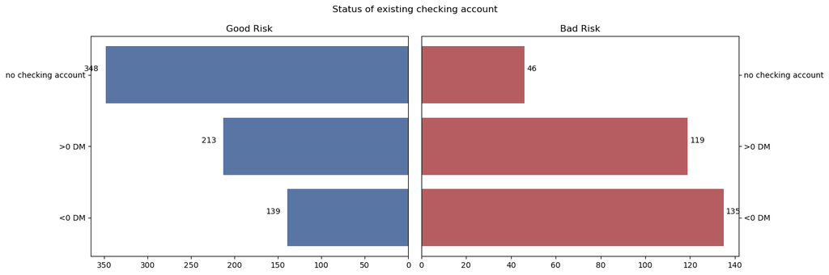

```python
import matplotlib.pyplot as plt
visualize_distribution("Status of existing checking account")
```

## Credit history

A credit history is a record of a borrower's responsible repayment of debts.

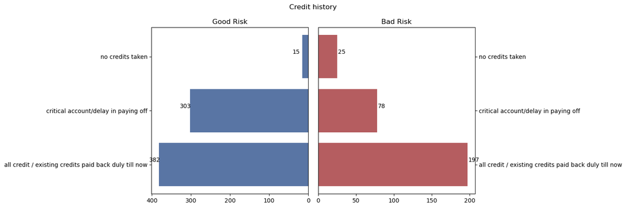

```python
visualize_distribution("Credit history")
```

## Purpose

The underlying reason an applicant is seeking a loan

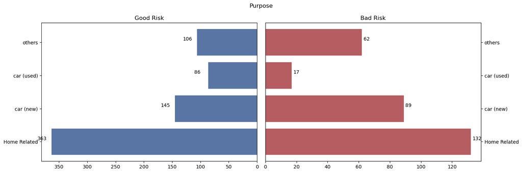

```python
visualize_distribution("Purpose")
```

## Savings account/bonds

A savings account is an interest-bearing deposit account held at a bank or other financial institution that provides a modest interest rate.m

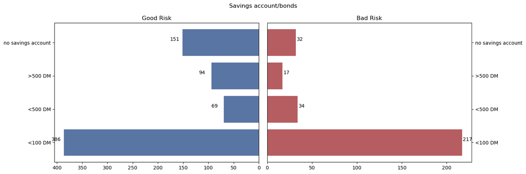

```python
visualize_distribution("Savings account/bonds")
```

Present employment since

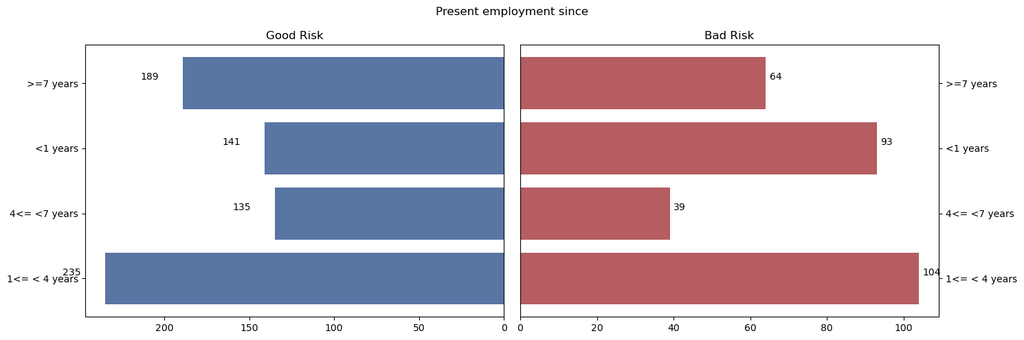

```python
visualize_distribution("Present employment since")
```

Installment rate in percentage of disposable income

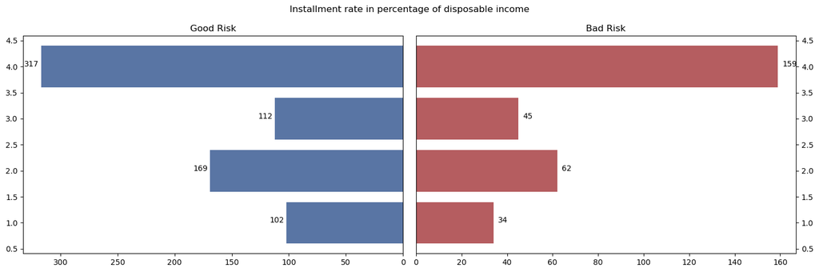

```python
visualize_distribution("Installment rate in percentage of disposable income")
```

Personal status and sex

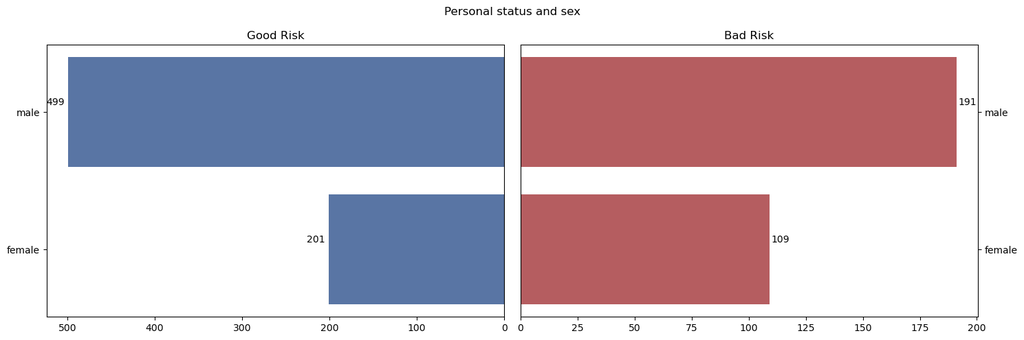

```python
visualize_distribution("Personal status and sex")
```

## Other debtors / guarantors

A guarantor is a person who guarantees to pay for someone else's debt if he or she should default on a loan obligation. A guarantor acts as a co-signer of sorts, in that they pledge their own assets or services if a situation arises in which the original debtor cannot perform their obligations

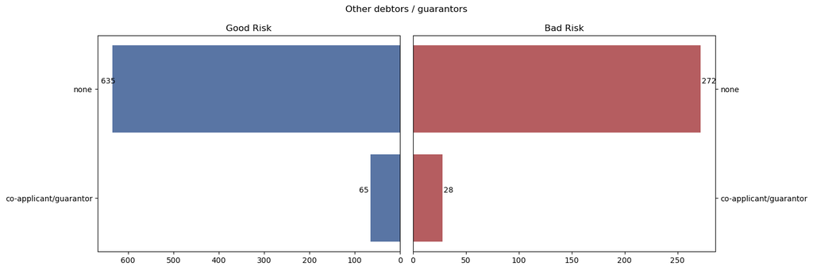

```python
visualize_distribution("Other debtors / guarantors")
```

Present residence since

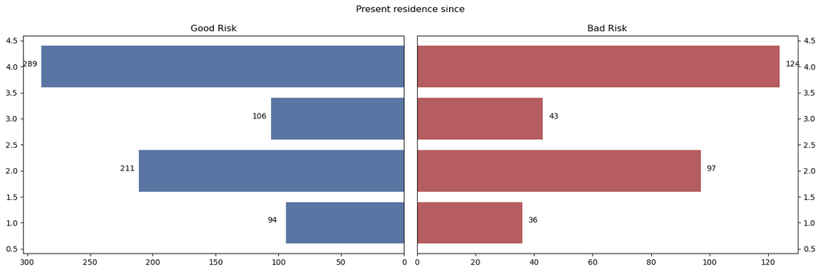

```python
visualize_distribution("Present residence since")
```

### Property

Borrower's property

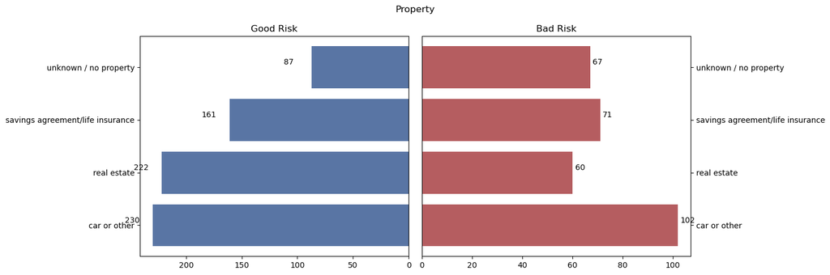

```python
visualize_distribution("Property")
```

### Other installment plans

Installment plan enable people to buy goods over an extended period of time, without having to put down very much money at the time of purchase

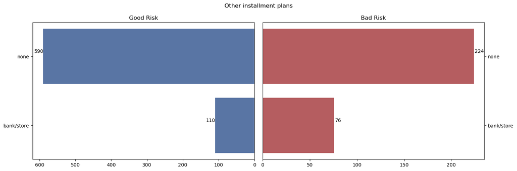

```python
visualize_distribution("Other installment plans")
```

Housing

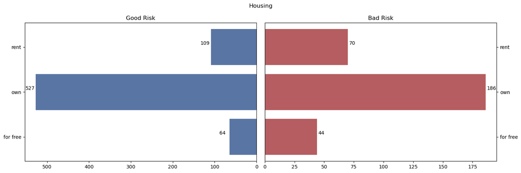

```python
visualize_distribution("Housing")
```

Number of existing credits at this bank

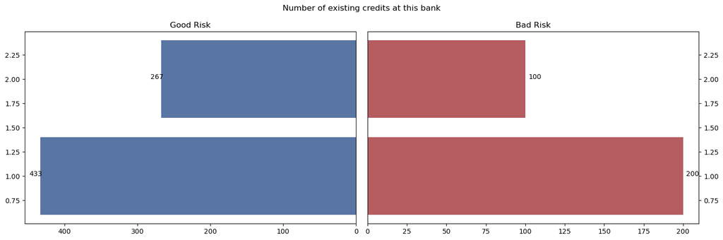

```python
visualize_distribution("Number of existing credits at this bank")
```

Number of people being liable to provide maintenance for

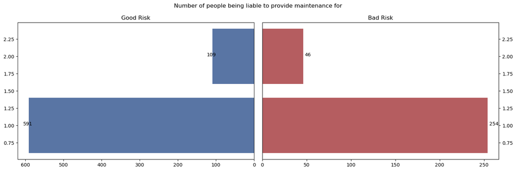

```python
visualize_distribution("Number of people being liable to provide maintenance for")
```

Foreign worker

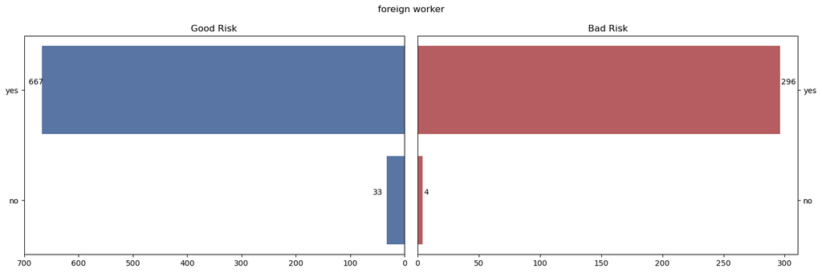

```python
visualize_distribution("foreign worker")
```

#### Duration in Year

Duration in month converted to years.

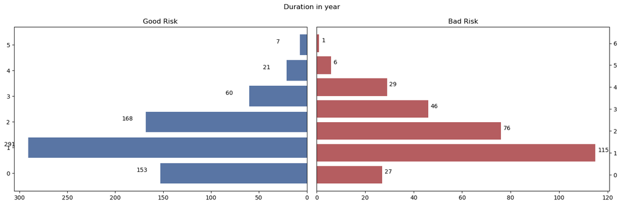

```python
df["Duration in year"]=df["Duration in month"].apply(lambda x: (floor(x/12)))
visualize_distribution("Duration in year")
```

#### Age category

age converted to categorica variable based on range

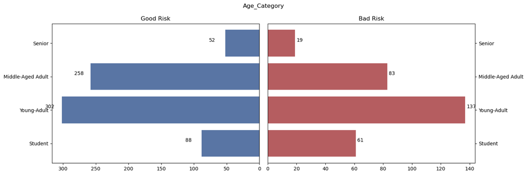

```python
age_interval = [18, 24, 35, 55, 120]
age_category = ['Student', 'Young-Adult', 'Middle-Aged Adult', 'Senior']
df["Age_Category"] = pd.cut(df["Age in years"], age_interval, labels=age_category)
visualize_distribution("Age_Category")
```

### Numerical Variable

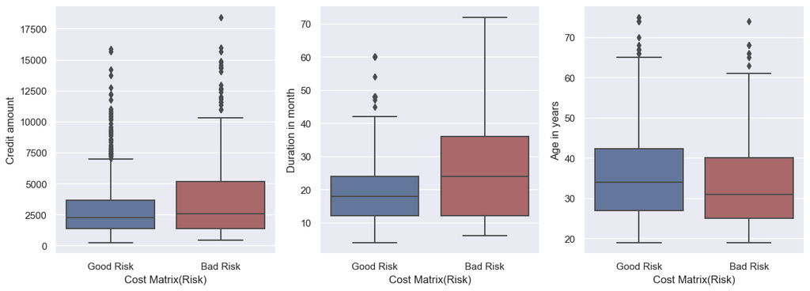

```python
sns.set()
f, axes = plt.subplots(1, 3,figsize=(15,5))
sns.boxplot(y=df["Credit amount"],x=df["Cost Matrix(Risk)"],orient='v' , ax=axes[0],palette=["#5975A4","#B55D60"]) #box plot
sns.boxplot(y=df["Duration in month"],x=df["Cost Matrix(Risk)"], orient='v' , ax=axes[1],palette=["#5975A4","#B55D60"]) #box plot
sns.boxplot(y=df["Age in years"],x=df["Cost Matrix(Risk)"], orient='v' , ax=axes[2],palette=["#5975A4","#B55D60"]) #box plot
plt.show()
```

### Feature Selection

```python
column_names_cat_stats=["Status of existing checking account","Credit history","Purpose",\
"Savings account/bonds","Present employment since",\
"Installment rate in percentage of disposable income","Personal status and sex",\
"Other debtors / guarantors","Present residence since","Property",\
"Other installment plans","Housing","Number of existing credits at this bank",\
"Job","Number of people being liable to provide maintenance for","Telephone","foreign worker"]

statistical_significance=[]
for attr in column_names_cat_stats:
    data_count=pd.crosstab(df[attr],df["Cost Matrix(Risk)"]).reset_index()
    obs=np.asarray(data_count[["Bad Risk","Good Risk"]])
    chi2, p, dof, expected = stats.chi2_contingency(obs)
    statistical_significance.append([attr,round(p,6)])
statistical_significance=pd.DataFrame(statistical_significance)
statistical_significance.columns=["Attribute","P-value"]
display(statistical_significance.style.apply(style_stats_specific_cell, axis=None))


statistical_significance=[]
column_names_cont_stats=["Credit amount","Age in years","Duration in month"]
good_risk_df = df[df["Cost Matrix(Risk)"]=="Good Risk"]
bad_risk_df = df[df["Cost Matrix(Risk)"]=="Bad Risk"]
for attr in column_names_cont_stats:
    statistic, p=stats.f_oneway(good_risk_df[attr].values,bad_risk_df[attr].values)
    statistical_significance.append([attr,round(p,6)])
statistical_significance=pd.DataFrame(statistical_significance)
statistical_significance.columns=["Attribute","P-value"]
display(statistical_significance.style.apply(style_stats_specific_cell, axis=None))
```

|  | Attribute | P-value |
| --- | --- | --- |
| 0 | Status of existing checking account | 0.000000 |
| 1 | Credit history | 0.000000 |
| 2 | Purpose | 0.000050 |
| 3 | Savings account/bonds | 0.000000 |
| 4 | Present employment since | 0.000422 |
| 5 | Installment rate in percentage of disposable income | 0.140033 |
| 6 | Personal status and sex | 0.020740 |
| 7 | Other debtors / guarantors | 1.000000 |
| 8 | Present residence since | 0.861552 |
| 9 | Property | 0.000029 |
| 10 | Other installment plans | 0.000476 |
| 11 | Housing | 0.000112 |
| 12 | Number of existing credits at this bank | 0.169304 |
| 13 | Job | 0.606737 |
| 14 | Number of people being liable to provide maintenance for | 1.000000 |
| 15 | Telephone | 0.278876 |
| 16 | foreign worker | 0.015831 |

|  | Attribute | P-value |
| --- | --- | --- |
| 0 | Credit amount | 0.000001 |
| 1 | Age in years | 0.003925 |
| 2 | Duration in month | 0.000000 |

```python
attr_significant=["Status of existing checking account","Credit history","Purpose",\
"Savings account/bonds","Present employment since",\
"Personal status and sex","Property","Other installment plans","Housing","foreign worker",\
"Credit amount","Age in years","Duration in month"]
target_variable=["Cost Matrix(Risk)"]
df=df[attr_significant+target_variable]
```

```python
col_cat_names=["Status of existing checking account","Credit history","Purpose",\
"Savings account/bonds","Present employment since",\
"Personal status and sex","Property","Other installment plans","Housing","foreign worker"]
for attr in col_cat_names:
    df = df.merge(pd.get_dummies(df[attr], prefix=attr), left_index=True, right_index=True)
    df.drop(attr,axis=1,inplace=True)

#converting target variable into numeric
risk={"Good Risk":1, "Bad Risk":0}
df["Cost Matrix(Risk)"]=df["Cost Matrix(Risk)"].map(risk)
```

```python
#view of the dataset for modelling
df.head()
```

|  | Credit amount | Age in years | Duration in month | Cost Matrix(Risk) | Status of existing checking account_<0 DM | Status of existing checking account_>0 DM | Status of existing checking account_no checking account | Credit history_all credit / existing credits paid back duly till now | Credit history_critical account/delay in paying off | Credit history_no credits taken | Purpose_Home Related | Purpose_car (new) | Purpose_car (used) | Purpose_others | Savings account/bonds_<100 DM | Savings account/bonds_<500 DM | Savings account/bonds_>500 DM | Savings account/bonds_no savings account | Present employment since_1<= < 4 years | Present employment since_4<= <7 years | Present employment since_<1 years | Present employment since_>=7 years | Personal status and sex_female | Personal status and sex_male | Property_car or other | Property_real estate | Property_savings agreement/life insurance | Property_unknown / no property | Other installment plans_bank/store | … |
| --- | --- | --- | --- | --- | --- | --- | --- | --- | --- | --- | --- | --- | --- | --- | --- | --- | --- | --- | --- | --- | --- | --- | --- | --- | --- | --- | --- | --- | --- | --- |
| 0 | 1169 | 67 | 6 | 1 | True | False | False | False | True | False | True | False | False | False | False | False | False | True | False | False | False | True | False | True | False | True | False | False | False | … |
| 1 | 5951 | 22 | 48 | 0 | False | True | False | True | False | False | True | False | False | False | True | False | False | False | True | False | False | False | True | False | False | True | False | False | False | … |
| 2 | 2096 | 49 | 12 | 1 | False | False | True | False | True | False | False | False | False | True | True | False | False | False | False | True | False | False | False | True | False | True | False | False | False | … |
| 3 | 7882 | 45 | 42 | 1 | True | False | False | True | False | False | True | False | False | False | True | False | False | False | False | True | False | False | False | True | False | False | True | False | False | … |
| 4 | 4870 | 53 | 24 | 0 | True | False | False | False | True | False | False | True | False | False | True | False | False | False | True | False | False | False | False | True | False | False | False | True | False | … |

Principal Component Analysis : Dimensionality Reduction

```python
X = df.drop(columns='Cost Matrix(Risk)').values #independent variables
y = df["Cost Matrix(Risk)"].values #target variables

pca = PCA(n_components=16)
X = pca.fit_transform(X)
```

### Modelling

#### Train/Test Split

```python
from sklearn.model_selection import train_test_split
# Spliting dataset into train and test version
X_train, X_test, y_train, y_test = train_test_split(X, y, test_size = 0.30,random_state=0)
```

#### Model: XGBClassifier

```python
from xgboost import XGBClassifier
model=XGBClassifier()
```

#### Accuracy Score

```python
from sklearn.metrics import accuracy_score
model.fit(X_train, y_train)
y_pred = model.predict(X_test)
print("Accuracy: ")
print(round(accuracy_score(y_test,y_pred)*100,2))
```

```
Accuracy:
76.0
```

#### ROC curve

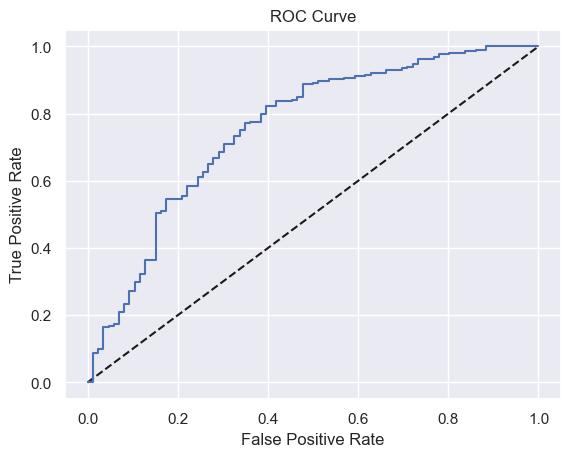

```python
from sklearn.metrics import roc_curve
y_pred_prob = model.predict_proba(X_test)[:,1]
fpr, tpr, thresholds = roc_curve(y_test, y_pred_prob)
plt.plot([0, 1], [0, 1], 'k--')
plt.plot(fpr, tpr)
plt.xlabel('False Positive Rate')
plt.ylabel('True Positive Rate')
plt.title('ROC Curve')
plt.show()
```

# Conclusion:

[output not shown]